```python
import sympy
from sympy import *
init_printing()

psi , eta ,epsilon, delta ,theta = symbols('psi eta epsilon delta theta',real=True )

sigma_I= eye(2)
sigma_Q= eye(2)
sigma_Q [1,1]=-1
sigma_U = Matrix([[0,1],[1,0]])
sigma_V = Matrix ([[0,-I],[I,0]])
```

```python
from IPython.display import HTML

HTML('''<script>
code_show=true;
function code_toggle() {
 if (code_show){
 $('div.input').hide();
 } else {
 $('div.input').show();
 }
 code_show = !code_show
}
$( document ).ready(code_toggle);
</script>
<form action="javascript:code_toggle()"><input type="submit" value="Click here to toggle on/off the raw code."></form>''')
```

# Jones matrix for a partial polarizer

see Jones et al. 2007

```python
Jb = Matrix([[eta, 0],
            [0  ,delta]])
Jb
```

$\displaystyle \left[\begin{matrix}\eta & 0\\0 & \delta\end{matrix}\right]$

# Mueller Matrix

A general definition can be given by $$ M_{ij} =\frac{1}{2} Tr (\sigma_i J \sigma_j J^{+}) $$

```python
Mpol = Matrix([ [trigsimp( trace(sigma_I *Jb *sigma_I *Jb.H)/2),trigsimp( trace(sigma_I *Jb *sigma_Q *Jb.H)/2),
 trigsimp( trace(sigma_I *Jb *sigma_U*Jb.H)/2),trigsimp( trace(sigma_I *Jb *sigma_V *Jb.H)/2)],
[trigsimp( trace(sigma_Q *Jb *sigma_I *Jb.H)/2),trigsimp( trace(sigma_Q *Jb *sigma_Q *Jb.H)/2),
 trigsimp( trace(sigma_Q *Jb *sigma_U*Jb.H)/2),trigsimp( trace(sigma_Q *Jb *sigma_V *Jb.H)/2)],
[trigsimp( trace(sigma_U *Jb *sigma_I *Jb.H)/2),trigsimp( trace(sigma_U *Jb *sigma_Q *Jb.H)/2),
 trigsimp( trace(sigma_U *Jb *sigma_U*Jb.H)/2),trigsimp( trace(sigma_U *Jb *sigma_V *Jb.H)/2)],
[trigsimp( trace(sigma_V *Jb *sigma_I *Jb.H)/2),trigsimp( trace(sigma_V *Jb *sigma_Q *Jb.H)/2),
 trigsimp( trace(sigma_V *Jb *sigma_U*Jb.H)/2),trigsimp( trace(sigma_V *Jb *sigma_V *Jb.H)/2)]])

Mpol
```

$\displaystyle \left[\begin{matrix}\frac{\delta^{2}}{2} + \frac{\eta^{2}}{2} & - \frac{\delta^{2}}{2} + \frac{\eta^{2}}{2} & 0 & 0\\- \frac{\delta^{2}}{2} + \frac{\eta^{2}}{2} & \frac{\delta^{2}}{2} + \frac{\eta^{2}}{2} & 0 & 0\\0 & 0 & \delta \eta & 0\\0 & 0 & 0 & \delta \eta\end{matrix}\right]$

# Rotation matrix

each angle involved in the computation of Mueller Matrices has to be taken into account with appropriate rotation matrices, in the following we consider

- $\xi $ the detector orientation
- $\psi$ the instrument orientation
- $\theta_{HWP}$ the HWP angle

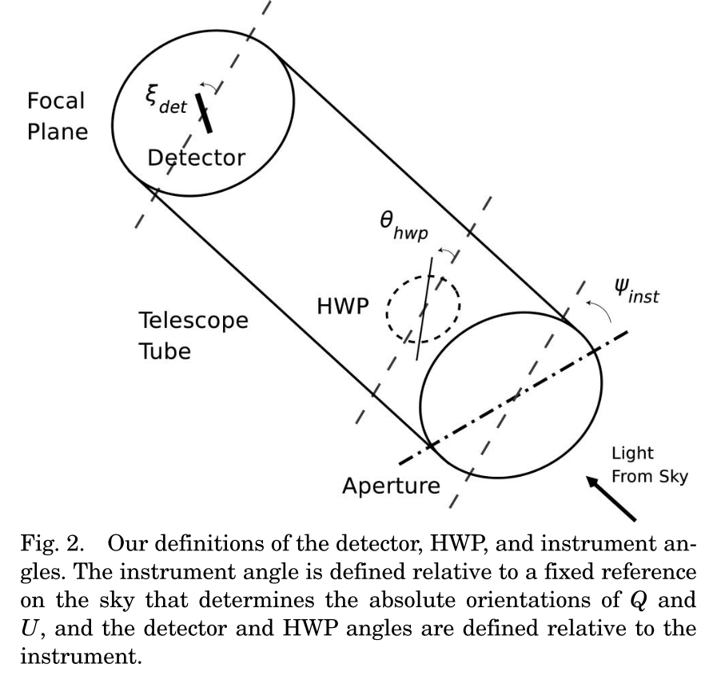

```python
R = Matrix([[cos(psi) , -sin(psi)],
            [sin(psi) ,cos(psi)]]).T
Mpsi = Matrix([ [trigsimp( trace(sigma_I *R *sigma_I *R.H)/2),trigsimp( trace(sigma_I *R *sigma_Q *R.H)/2),
 trigsimp( trace(sigma_I *R *sigma_U*R.H)/2),trigsimp( trace(sigma_I *R *sigma_V *R.H)/2)],
[trigsimp( trace(sigma_Q *R *sigma_I *R.H)/2),trigsimp( trace(sigma_Q *R *sigma_Q *R.H)/2),
 trigsimp( trace(sigma_Q *R *sigma_U*R.H)/2),trigsimp( trace(sigma_Q *R *sigma_V *R.H)/2)],
[trigsimp( trace(sigma_U *R *sigma_I *R.H)/2),trigsimp( trace(sigma_U *R *sigma_Q *R.H)/2),
 trigsimp( trace(sigma_U *R *sigma_U*R.H)/2),trigsimp( trace(sigma_U *R *sigma_V *R.H)/2)],
[trigsimp( trace(sigma_V *R *sigma_I *R.H)/2),trigsimp( trace(sigma_V *R *sigma_Q *R.H)/2),
 trigsimp( trace(sigma_V *R *sigma_U*R.H)/2),trigsimp( trace(sigma_V *R *sigma_V *R.H)/2)]])

Mpsi
```

$\displaystyle \left[\begin{matrix}1 & 0 & 0 & 0\\0 & \cos{\left(2 \psi \right)} & \sin{\left(2 \psi \right)} & 0\\0 & - \sin{\left(2 \psi \right)} & \cos{\left(2 \psi \right)} & 0\\0 & 0 & 0 & 1\end{matrix}\right]$

```python
xi = symbols('xi ',real=True )
Mxi = Mpsi.subs (psi,xi )
Mxi
```

$\displaystyle \left[\begin{matrix}1 & 0 & 0 & 0\\0 & \cos{\left(2 \xi \right)} & \sin{\left(2 \xi \right)} & 0\\0 & - \sin{\left(2 \xi \right)} & \cos{\left(2 \xi \right)} & 0\\0 & 0 & 0 & 1\end{matrix}\right]$

```python
Mtheta = Mpsi.subs (psi,theta )
Mtheta
```

$\displaystyle \left[\begin{matrix}1 & 0 & 0 & 0\\0 & \cos{\left(2 \theta \right)} & \sin{\left(2 \theta \right)} & 0\\0 & - \sin{\left(2 \theta \right)} & \cos{\left(2 \theta \right)} & 0\\0 & 0 & 0 & 1\end{matrix}\right]$

# Coefficients for a perfect polarizer

$\delta=0, \eta=1 $

```python
simplify ( ( Mpol* Mxi *Mpsi  ) .subs(delta,0 ).subs(eta,1)  )[0,:]
```

$\displaystyle \left[\begin{matrix}\frac{1}{2} & \frac{\cos{\left(2 \psi + 2 \xi \right)}}{2} & \frac{\sin{\left(2 \psi + 2 \xi \right)}}{2} & 0\end{matrix}\right]$

# Mueller Matrix for a HWP

```python
T, rho,c,s  = symbols('T rho c s ',real=True )
M_HWP =Matrix([[T,rho ,0,0],
               [rho,T,0,0],
               [0,0,c,-s],
               [0,0,s,c]])
M_HWP
```

$\displaystyle \left[\begin{matrix}T & \rho & 0 & 0\\\rho & T & 0 & 0\\0 & 0 & c & - s\\0 & 0 & s & c\end{matrix}\right]$

```python
M = (Mpol* Mxi* Mtheta.T*M_HWP*Mtheta*Mpsi)
```

The total Muller matrix is defined as :

$M = M_{pol} M_{\xi} M_{\theta} ^T M_{HWP} M_{\theta} M_{\psi} $

Comparing results from Bryan et al 2010 eq. 15-17 below

# Coefficients in the limit of no HWP

$T= c=1 ,\rho=s=0$ we also consider $\xi_{det} =0$

```python
simplify ( M .subs(xi,0 ).subs(T,1 ).subs(c,1).subs(rho,0).subs(s,0) )[0,:]
```

$\displaystyle \left[\begin{matrix}\frac{\delta^{2}}{2} + \frac{\eta^{2}}{2} & \frac{\left(- \delta^{2} + \eta^{2}\right) \cos{\left(2 \psi \right)}}{2} & \frac{\left(- \delta^{2} + \eta^{2}\right) \sin{\left(2 \psi \right)}}{2} & 0\end{matrix}\right]$

# Coefficients with ideal HWP

$T= 1, c=-1 ,\rho=s=0$

we also consider $\xi_{det} =0$ see eq. 18 of Bryan et al.

```python
(simplify ( M .subs(xi,0 ).subs(T,1 ).subs(c,-1).subs(rho,0).subs(s,0) )[0,:] )
```

$\displaystyle \left[\begin{matrix}\frac{\delta^{2}}{2} + \frac{\eta^{2}}{2} & \frac{\left(- \delta^{2} + \eta^{2}\right) \cos{\left(2 \psi \right)} \cos{\left(4 \theta \right)}}{2} + \frac{\left(\delta^{2} - \eta^{2}\right) \left(\cos{\left(2 \psi - 4 \theta \right)} - \cos{\left(2 \psi + 4 \theta \right)}\right)}{4} & \frac{\left(- \delta^{2} + \eta^{2}\right) \sin{\left(2 \psi + 4 \theta \right)}}{2} & 0\end{matrix}\right]$

# Coefficient with non -ideal HWP

```python
tmp = (simplify ( M .subs(xi,0 )  )  )
tmp [0]
```

$\displaystyle \frac{T \left(\delta^{2} + \eta^{2}\right)}{2} - \frac{\rho \left(\delta^{2} - \eta^{2}\right) \cos{\left(2 \theta \right)}}{2}$

```python
trigsimp(tmp[1].subs(sin(2*theta)**2, cos(2*theta)**2 - cos(4*theta)))
```

$\displaystyle - \frac{\left(\frac{c \left(1 - \cos{\left(4 \theta \right)}\right) \left(\delta^{2} - \eta^{2}\right)}{2} + \left(T \left(\delta^{2} - \eta^{2}\right) \cos{\left(2 \theta \right)} - \rho \left(\delta^{2} + \eta^{2}\right)\right) \cos{\left(2 \theta \right)}\right) \cos{\left(2 \psi \right)}}{2} - \frac{\left(- T \left(\delta^{2} - \eta^{2}\right) \cos{\left(2 \theta \right)} + c \left(\delta^{2} - \eta^{2}\right) \cos{\left(2 \theta \right)} + \rho \left(\delta^{2} + \eta^{2}\right)\right) \sin{\left(2 \psi \right)} \sin{\left(2 \theta \right)}}{2}$

```python
trigsimp(tmp[2].subs(sin(2*theta)**2, cos(2*theta)**2 - cos(4*theta)))
```

$\displaystyle - \frac{\left(\frac{c \left(1 - \cos{\left(4 \theta \right)}\right) \left(\delta^{2} - \eta^{2}\right)}{2} + \left(T \left(\delta^{2} - \eta^{2}\right) \cos{\left(2 \theta \right)} - \rho \left(\delta^{2} + \eta^{2}\right)\right) \cos{\left(2 \theta \right)}\right) \sin{\left(2 \psi \right)}}{2} + \frac{\left(- T \left(\delta^{2} - \eta^{2}\right) \cos{\left(2 \theta \right)} + c \left(\delta^{2} - \eta^{2}\right) \cos{\left(2 \theta \right)} + \rho \left(\delta^{2} + \eta^{2}\right)\right) \sin{\left(2 \theta \right)} \cos{\left(2 \psi \right)}}{2}$

If we define $\epsilon= \delta^2/\eta^2$ and factorize out $\eta^2 *(1+\epsilon)/2\equiv C $ and work out a bit the trigonometry we get :

- $ M_{II} = C \left[ T + \frac{(1-\epsilon)}{(1+\epsilon)} \rho \cos (2\theta) \right] $
- $ M_{IQ} = C \left[ \rho \cos(2\theta +2 \psi ) + \frac{(1-\epsilon)}{(1+\epsilon)} \left(\frac{(T+c)}{2} \cos 2\psi + \frac{(T-c)}{2} \cos ( 2\psi +4\theta) \right) \right] $
- $ M_{IU} = C \left[ \rho \sin(2\theta +2 \psi ) + \frac{(1-\epsilon)}{(1+\epsilon)} \left(\frac{(T+c)}{2} \sin 2\psi + \frac{(T-c)}{2} \sin ( 2\psi +4\theta) \right) \right] $

notice that for the cases shown above (ideal HWP and no-HWP ) the expressions above simplify as expected.

These weights are implemented in toast in a new operator `OpMuellerPointingHpix` in the `mueller_matrix` branch.